# T-tests!

Well this post is quite delayed. In the meantime I've been quite busy so I have only found time for another post now.

In this post I outline my further exploration into inferential statistics, specifically t-tests. I hope this can be of help to some people, who struggle with statistics concepts.

Stay tuned for further posts and information on my journey through DATA.

# T- tests

**First, what are t-tests?**  
Well, t-tests are used when we **don't** know population parameters, just like we use z-tests when we **do** know population parameters. Here I show worked examples of one-sample and two-sample t-tests. A t-test can be carried out on dependent and independent samples. A dependent sample is a repeated measure, which means that a survey is carried on the same subject. this can mean that this may be a pre-test, post-test or longitudal (between different points in time) test. A independent sample is a measure where, the result does not depend on a previous test. Such as a survey of mean age in Zimbabwe and another in Mozambique. A independent samples are "between-subject designs" while dependent samples are "within-subject designs".

Here I make use of two worked examples to firstly show how to evaluate dependent samples and then independent samples. **All data in the dataframes is not real** it's completely fake and only used for the purpose of showing how t-tests work.

```python
import pandas as pd
import numpy as np
import matplotlib.pylab as plt
import seaborn as sns
```

## **Dependent sample example: AIDS rates in South Africa between 2001 and 2011**

I created a dataframe which shows measures of AIDS prevalence in 15 random districts in South Africa.

```python
df = pd.DataFrame(data = {"2001": np.random.normal(24.8,2.15,15), "2011": np.random.normal(29.5,2.76,15)})
df.head()
```

|  | 2001 | 2011 |
| --- | --- | --- |
| 0 | 27.081426 | 32.051878 |
| 1 | 28.666287 | 29.309436 |
| 2 | 26.245007 | 30.401871 |
| 3 | 24.936959 | 27.730607 |
| 4 | 25.887478 | 25.763822 |

The dependent variable here (the outcome) is the AIDS prevelance rate while the independent variable is the year. Now, lets devise our hypothesis.

My null ($H_0$) and alternative ($H_1$) hypothesis: $$ H_0: \mu_{2011} -\mu_{2001} = 0 $$$$ H_1: \mu_{2011} -\mu_{2001} ≠ 0 $$

**Make some plots of the data**

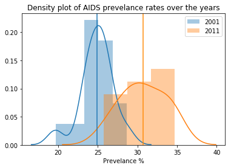

```python
sns.distplot(df['2001'], label = "2001")
sns.distplot(df['2011'], label = "2011")
plt.axvline(df['2001'].mean())
plt.axvline(df['2011'].mean(),c = '#FF8C09')
plt.title("Density plot of AIDS prevelance rates over the years")
plt.xlabel("Prevelance %")
plt.legend();
```

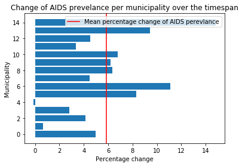

```python
diff = df['2011']-df['2001']

plt.barh(df.index,diff)

plt.title("Change of AIDS prevelance per municipality over the timespan")
plt.xlabel("Percentage change")
plt.ylabel("Municipality")

plt.axvline(diff.mean(),c='red',label='Mean percentage change of AIDS perevlance')
plt.legend();
```

### STEP 1: Find the critical value

For every hypothesis test we have to create a alpha level, which is the probability of rejecting the null hypothesis, when the null hypothesis is true. Shorthand, the alpha level is really the probability, that we get a Type I error. Most of the time we use a alpha level of 5% (0.05), this means we are willing to risk 5% of getting a Type I error. In t-tests we use a t-table to find the t-critical value. The critical value is the value that splits the graph into acceptable and non-acceptable values, so if we have a alpha level of 5%, we take 5% off the tails, in a two tailed test we take 2.5% off each tail. Use a t-table such as [here](https://www.stat.tamu.edu/~lzhou/stat302/T-Table.pdf).

So from this table we find that we get a **t-critical value of ±2.145**. We find this with 14 degrees of freedom (remember degrees of freedom are size of sample minus one) and a p-value of 2.5% off each tail.

### Step 2: Find the means and standard deviations

```python
print ("2001 mean: " + str(df['2001'].mean()))
print ("2011 mean: " + str(df['2011'].mean()))
print ("2001 standard deviation: " + str(df['2001'].std()))
print ("2011 standard deviation: " + str(df['2011'].std()))
```

```
2001 mean: 24.876672810917867
2011 mean: 30.72369546934397
2001 standard deviation: 2.050758357653504
2011 standard deviation: 2.8237156632759803
```

The point estimate is the single value given as an estimate of a parameter of a population. here this is the 2011 mean minus the 2001 mean.

```python
PE = (df['2011'].mean())-(df['2001'].mean())
PE
```

```
5.847022658426102
```

Now calculate the standard deviation of the differences by creating a new column to record the differnces in each row and taking the deviations of all these.

```python
df['Diff'] = df['2011'] - df['2001']
std = df.Diff.std()
std
```

```
3.9027282742166203
```

### STEP 4: Calculate the t-statistic

Now lets calculate the t-statistic. Afterwards we wil compare this with the t-critical value. If the t-statistic is greater than the t-critical value, then we reject the null hypothesis in favor of the alternative.

$$ t-statistic = \frac{(\bar{X}_{2011}-\bar{X}_{2001})-(\mu_{2011}-\mu_{2001})}{SEM} $$

Where $(\bar{X}_{2011}-\bar{X}_{2001})$ is the point estimate, $(\mu_{2011}-\mu_{2001})$ is zero here because of our hypothesis, $s$ is the standard error

## **Independent sample example: AIDS rates in South Africa and Lesotho in 2018**

I created a dataframe which shows measures of AIDS prevalence in 23 random districts in South Africa and 27 random districts in Lesotho.

```python
SA = pd.DataFrame(data = {"South Africa": np.random.normal(18.8,3.23,23)})
Lesotho = pd.DataFrame(data = {"Lesotho": np.random.normal(23.8,2.46,27)})
```

```python
SA.head()
```

|  | South Africa |
| --- | --- |
| 0 | 12.845046 |
| 1 | 17.209565 |
| 2 | 18.249125 |
| 3 | 19.125815 |
| 4 | 25.540817 |

```python
Lesotho.head()
```

|  | Lesotho |
| --- | --- |
| 0 | 22.517536 |
| 1 | 23.592696 |
| 2 | 25.728880 |
| 3 | 18.847293 |
| 4 | 23.821667 |

Now thats my two independent samples, now lets devise our hypothesis:

My null ($H_0$) and alternative ($H_1$) hypothesis: $$ H_0: \mu_{Lesotho} -\mu_{South Africa} = 0 $$$$ H_1: \mu_{Lesotho} -\mu_{South AFrica} ≠ 0 $$

**Again, some plots of the data (you don't really have to do this)**

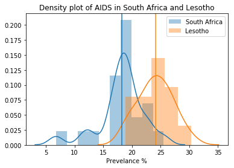

```python
sns.distplot(SA['South Africa'], label = "South Africa")
sns.distplot(Lesotho['Lesotho'], label = "Lesotho")
plt.axvline(SA['South Africa'].mean())
plt.axvline(Lesotho['Lesotho'].mean(),c = '#FF8C09')
plt.title("Density plot of AIDS in South Africa and Lesotho")
plt.xlabel("Prevelance %")
plt.legend();
```

### Step 1: Find the t-critical value

Once again just as explained above, use a t-table such as [this one](https://www.stat.tamu.edu/~lzhou/stat302/T-Table.pdf), to find the critical value - again with a alpha value of 0.05. However, this time take into account the degrees of freedom for the South Africa sample is 22 and the degrees of freedom for the Lesotho sample is 26. In independent samples we get the degree of freedom by adding the degrees of freedom of all samples together, here this equals 48. Therefore we get a t-critical value of around **±2.009**

### Step 2: FInd means and standard deviations

```python
print ("South Africa mean: " + str(SA['South Africa'].mean()))
print ("Lesotho mean: " + str(Lesotho['Lesotho'].mean()))
print ("South Africa standard deviation: " + str(SA['South Africa'].std()))
print ("Lesotho standard deviation: " + str(Lesotho['Lesotho'].std()))
```

```
South Africa mean: 18.22743457567963
Lesotho mean: 24.08869999475644
South Africa standard deviation: 3.9344673071137346
Lesotho standard deviation: 3.0001899681263486
```

Find the point estimate

```python
PE = (Lesotho['Lesotho'].mean())-(SA['South Africa'].mean())
PE
```

```
5.861265419076808
```

### Step 3: Find the standard error of the mean

In independent samples we can have different sample sizes, so we use a different formula to that of dependent samples. Also, in independent samples we subtract one sample (normal distribution) from the other. Subtracting normal distributions gives us the formula: $s=\sqrt{s_1^2 + s_2^2}$. We can use this formula to derive the standard error of mean (SEM) of indpendent variables: $$ SEM = \frac{s}{\sqrt{n}} = \frac{\sqrt{s_1^2 + s_2^2}}{\sqrt{n}} = \sqrt\frac{s_1^2 + s_2^2}{n} = \sqrt{\frac{s_1^2}{n_1} + \frac{s_2^2}{n_2}} $$

Where $s$ are the standard deviations and $n$ is the size of the sample.

Using this SEM formula, we can calculate the SEM: $$ SEM = \sqrt{\frac{s_{Lesotho}^2}{n_{Lesotho}} + \frac{s_{SA}^2}{n_{SA}}} $$

### Step 4: Calculate the t-statistic

The t-statistic is calculated just like in dependent samples. So lets calculate this value: $$ t-statistic = \frac{(\bar{X}_{Lesotho}-\bar{X}_{SA})-(\mu_{Lesotho}-\mu_{SA})}{SEM} $$

Where $(\bar{X}_{Lesotho}-\bar{X}_{SA})$ is once again the point estimate and $(\mu_{Lesotho}-\mu_{SA})$ will again remain zero, just like in our hypothesis.

I realised that there quite a lot mistakes in my first post, ill correct these soon!